# Forecasting

In this document, we will present forecasting methods that can be used with time series data. Here, we will illustrate how the algorithm is working by forecasting evolution of hospitalizations due to COVID-19, in the state of Colorado. To do so, we are using data available on [covidtracking.com](https://covidtracking.com/data). This document is written to be adapted to your own dataset and forecasting needs.

## Import of the libraries:

```r
library(tidyverse)
library(finalfit)
library(broom)
library(tsibble)
library(fable)
library(feasts)
library(forecast)
library(MLmetrics)
library(reshape2)
library(nnfor)
library(imputeTS)
```

## Import of the dataset:

To import your dataset, juste replace data.csv by the path of your data. The missing glimpse function allows you tu visualize missing data for each column of your dataset.

```r
data <- read_csv("data.csv")
missing_glimpse(data)
```

```
##                                                             label var_type
## date                                                         date   <date>
## state                                                       state    <chr>
## death                                                       death    <dbl>
## deathConfirmed                                     deathConfirmed    <dbl>
## deathIncrease                                       deathIncrease    <dbl>
## deathProbable                                       deathProbable    <dbl>
## hospitalized                                         hospitalized    <dbl>
## hospitalizedCumulative                     hospitalizedCumulative    <dbl>
## hospitalizedCurrently                       hospitalizedCurrently    <dbl>
## hospitalizedIncrease                         hospitalizedIncrease    <dbl>
## inIcuCumulative                                   inIcuCumulative    <dbl>
## inIcuCurrently                                     inIcuCurrently    <dbl>
## negative                                                 negative    <dbl>
## negativeIncrease                                 negativeIncrease    <dbl>
## negativeTestsAntibody                       negativeTestsAntibody    <dbl>
## negativeTestsPeopleAntibody           negativeTestsPeopleAntibody    <dbl>
## negativeTestsViral                             negativeTestsViral    <dbl>
## onVentilatorCumulative                     onVentilatorCumulative    <dbl>
## onVentilatorCurrently                       onVentilatorCurrently    <dbl>
## positive                                                 positive    <dbl>
## positiveCasesViral                             positiveCasesViral    <dbl>
## positiveIncrease                                 positiveIncrease    <dbl>
## positiveScore                                       positiveScore    <dbl>
## positiveTestsAntibody                       positiveTestsAntibody    <dbl>
## positiveTestsAntigen                         positiveTestsAntigen    <dbl>
## positiveTestsPeopleAntibody           positiveTestsPeopleAntibody    <dbl>
## positiveTestsPeopleAntigen             positiveTestsPeopleAntigen    <dbl>
## positiveTestsViral                             positiveTestsViral    <dbl>
## recovered                                               recovered    <dbl>
## totalTestEncountersViral                 totalTestEncountersViral    <dbl>
## totalTestEncountersViralIncrease totalTestEncountersViralIncrease    <dbl>
## totalTestResults                                 totalTestResults    <dbl>
## totalTestResultsIncrease                 totalTestResultsIncrease    <dbl>
## totalTestsAntibody                             totalTestsAntibody    <dbl>
## totalTestsAntigen                               totalTestsAntigen    <dbl>
## totalTestsPeopleAntibody                 totalTestsPeopleAntibody    <dbl>
## totalTestsPeopleAntigen                   totalTestsPeopleAntigen    <dbl>
## totalTestsPeopleViral                       totalTestsPeopleViral    <dbl>
## totalTestsPeopleViralIncrease       totalTestsPeopleViralIncrease    <dbl>
```

[output cut: 29 more lines]

```
## positiveTestsPeopleAntigen         633     20147            97.0
## positiveTestsViral                8958     11822            56.9
## recovered                        12003      8777            42.2
## totalTestEncountersViral          5231     15549            74.8
## totalTestEncountersViralIncrease 20780         0             0.0
## totalTestResults                 20614       166             0.8
## totalTestResultsIncrease         20780         0             0.0
## totalTestsAntibody                4789     15991            77.0
## totalTestsAntigen                 3421     17359            83.5
## totalTestsPeopleAntibody          2200     18580            89.4
## totalTestsPeopleAntigen            999     19781            95.2
## totalTestsPeopleViral             9181     11599            55.8
## totalTestsPeopleViralIncrease    20780         0             0.0
## totalTestsViral                  14516      6264            30.1
## totalTestsViralIncrease          20780         0             0.0
```

Here, you can define a dependent variable `dep_var`, that will be forecast with respect to an explanatory variable `exp_var`.

```r
dep_var <- 'hospitalizedCurrently'
exp_var <- 'date'
```

Now, you have to convert data to make it usable by our models. You can also filter data. Here we use it to get only data related to Colorado. If you don’t need to do so, you can just write `data <- as_tsibble(data)`.

```r
data <- as_tsibble(data %>% filter(state=="CO"), index = date)
data[dep_var] <- na.interp(data[dep_var])
```

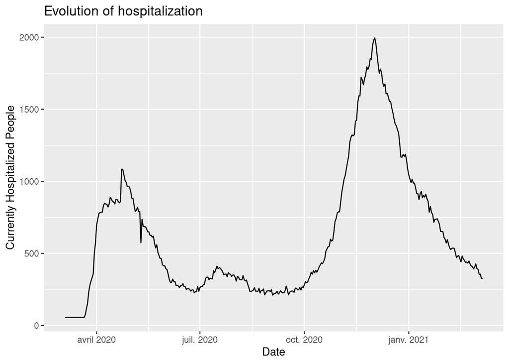

```r
data %>% ggplot(aes_string(x = exp_var, y = dep_var))+
  geom_line()+  ggtitle('Evolution of hospitalization')+
  xlab('Date')+
  ylab('Currently Hospitalized People')
```

The method we will be using to forecast is the exponential smoothing. This general method however presents some variations. We will first test a few of them, before choosing the one that might give us eh best results.

```r
data %>%
  stretch_tsibble(.init = 10) %>%
  model(
    SES = ETS(hospitalizedCurrently ~ error("A") + trend("N") + season("N")),
    Holt = ETS(hospitalizedCurrently ~ error("A") + trend("A") + season("N")),
    Damped = ETS(hospitalizedCurrently ~ error("A") + trend("Ad") +
                   season("N"))
  ) %>%
  forecast(h = 1) %>%
  accuracy(data)
```

```
## # A tibble: 3 x 10
##   .model .type     ME  RMSE   MAE   MPE  MAPE  MASE RMSSE   ACF1
##   <chr>  <chr>  <dbl> <dbl> <dbl> <dbl> <dbl> <dbl> <dbl>  <dbl>
## 1 Damped Test  -0.586  34.7  22.4 0.131  4.16 0.214 0.242 -0.128
## 2 Holt   Test  -0.119  34.6  22.6 0.335  4.20 0.216 0.241 -0.109
## 3 SES    Test   0.800  36.4  23.7 0.287  4.44 0.226 0.254  0.150
```

To chose our method, we need to observe the MSE and the MAPE computed for each of them. I our case, Holt and Damped seem to produce similar accuracies. We decide here to keep the Damped one. We finally can forecast data, after we decided how many values we would like to predict. This values is held in the `frc_length` variable. The following code can now plot the forecast evolution.

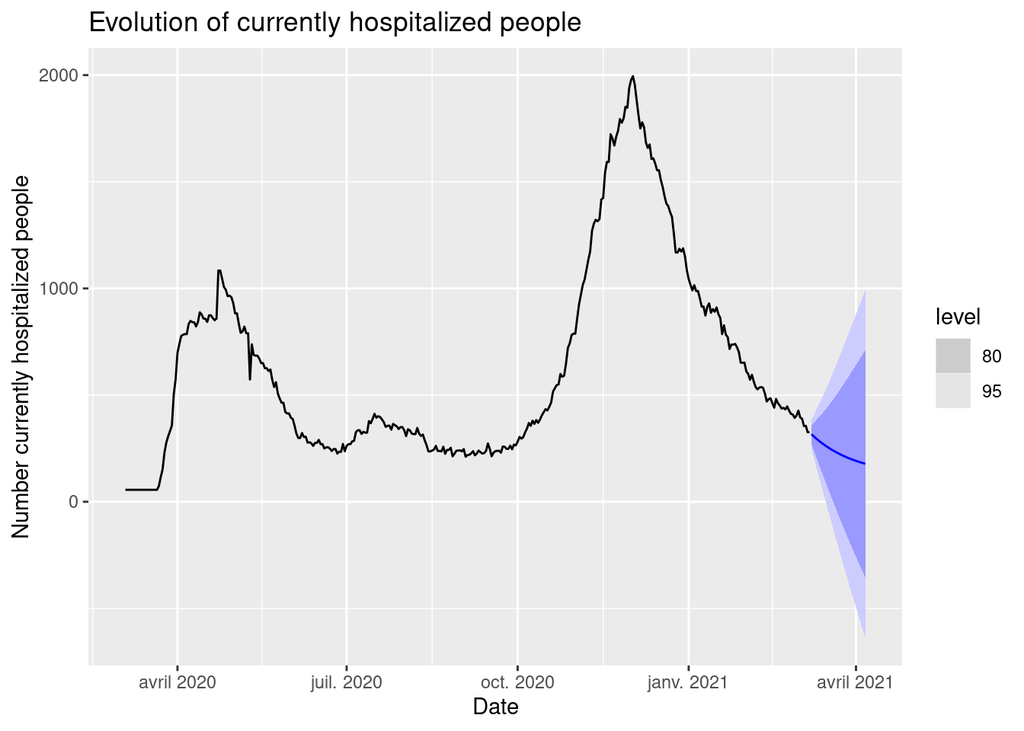

```r
frc_length <- 30

frc <- data %>%
  model(Damped = ETS(hospitalizedCurrently ~ error("A") + trend("Ad") + season("N"))) %>%
  forecast(h = frc_length)

frc %>%
  autoplot(data) +
  labs(x="Date", y="Number currently hospitalized people",
       title = "Evolution of currently hospitalized people")
```

We also directly can access the forecast values:

```r
  print(pull(frc,'.mean'))
```

```
##  [1] 316.6562 308.5574 300.7920 293.3461 286.2068 279.3613 272.7975 266.5040
##  [9] 260.4695 254.6834 249.1354 243.8158 238.7152 233.8245 229.1351 224.6387
## [17] 220.3275 216.1936 212.2299 208.4294 204.7853 201.2912 197.9409 194.7285
## [25] 191.6484 188.6950 185.8632 183.1480 180.5445 178.0481
```